# Bad Graphs

author: “Duncan”  
date: “07/07/2019”

**Duration - 1 hour**

In this lab we will review some “bad graphs” to identify how they could be improved

Here are some examples of bad charts.

For each plot explain the problem(s) with the chart, and suggest possible improvements.

# 1 Question 1

This first one is a bit of a cheat - it was a parody of another chart that showed world population by country.

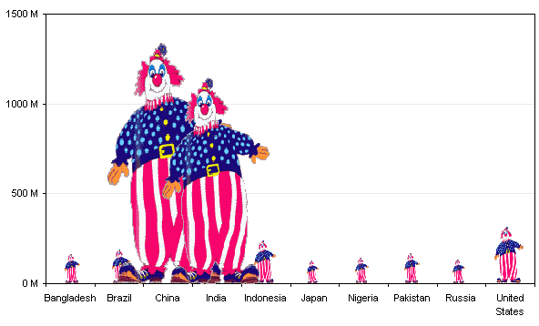

# 2 Question 2

Let’s turn to economics. What issues do you see with this chart?

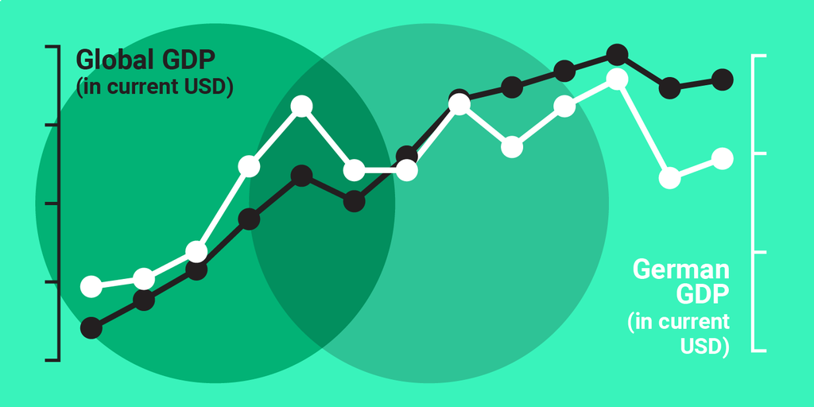

Figure 2. World and German GDP

# 3 Question 3

Here is CNN’s exciting variant on a pie chart. “variant on a pie chart” should always be an alarm bell in your mind. What are the issues here?

[figure not shown]

Figure 3. Cannabis Usage by Age in US

# 4 Question 4

Here’s a familar variant on a pie chart.

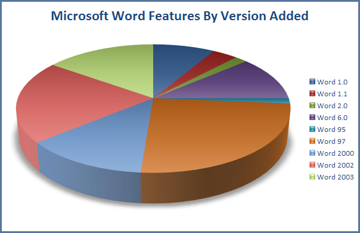

Figure 4. 3D Pie Chart

# 5 Question 5

What do you see wrong with this chart?

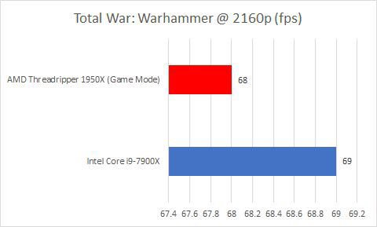

Figure 5. A major impact on performance?

# 6 Question 6

Here’s another visualisation using bar charts poorly.

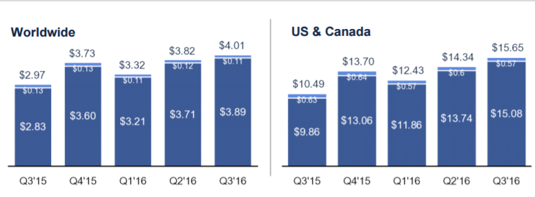

Figure 6. Facebook Revenue per User by Region

# 7 Question 7

This one is rather special.

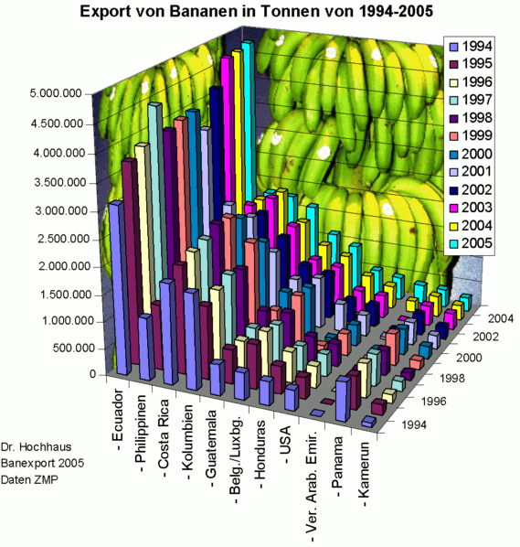

Figure 7. Banana Exports by Country and Year

# 8 Question 8

Last bar chart…

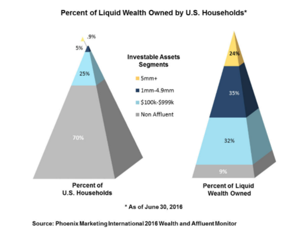

Figure 8. Percent of Liquid Wealth owned by US Households

# 9 Question 9

Here’s a very exciting line chart for us to study.

[figure not shown]

Figure 9. Diamonds are not a girl’s best friend

# 10 Question 10

[figure not shown]

Figure 10. Nobel Prize Winners by Nationality and Field

# 11 Question 11

So these flow charts are supposed to show what proportion of high school kids have the same political beliefs as their parents. But most people struggle to read these graphs.

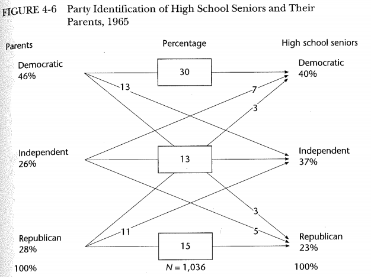

Figure 11. Do high school seniors get their political alignment from their parents?

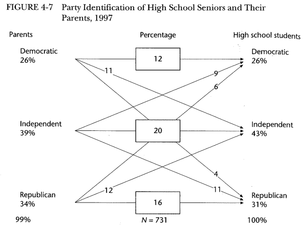

Figure 11. Do high school seniors get their political alignment from their parents?

Here, in the interests of fairness, is a better visualisation of the same data.

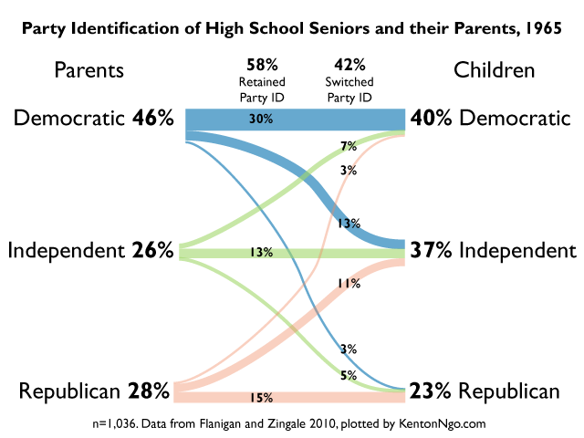

Figure 12. Do high school seniors get their political alignment from their parents (revised)?

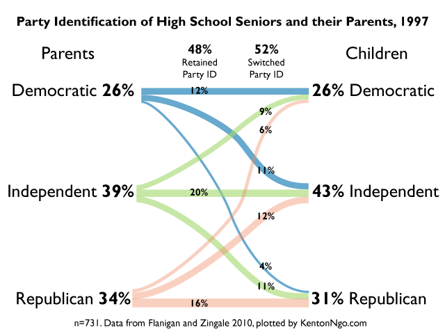

Figure 12. Do high school seniors get their political alignment from their parents (revised)?

Why does the first visualisation fail?

# 12 Question 12

So, this is a graph about the rise and fall of Microsoft (denoted as Win Tel in the first graph). Both graphs use the same data. Which one communicates the rise and fall of Microsoft more clearly, and why?

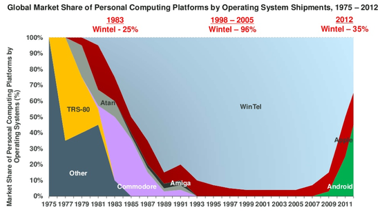

Figure 13. The Rise and Fall of Microsoft in Two Graphs

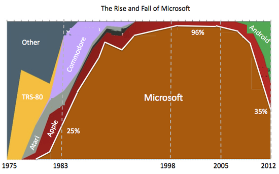

Figure 13. The Rise and Fall of Microsoft in Two Graphs